# R Notebook

code to install and load dataset packages

```r
install.packages("devtools")
```

```r
devtools::install_github('codeclan/CodeClanData')
```

```r
library(CodeClanData)
```

```r
beer
```

| brand | brewer | percent | calories | carbohydrates |
| --- | --- | --- | --- | --- |
| Beamish Irish Cream Stout | Beamish - Crawford (Ireland) | 5.00 | 146 | 10.00 |
| Beck's Beer | Brauerei Beck (Germany) | 2.30 | 143 | 3.90 |
| Beck's Light | Brauerei Beck (Germany) | 4.80 | 64 | 11.00 |
| Dragon Stout | Desnoes - Goeddes (Jamaica) | 5.10 | 220 | 11.00 |
| Greenall's Cheshire English Pub Beer | Greenall Whitley PLC (England) | 5.00 | 142 | 9.50 |
| Guiness Draught - Bottle | Guinness (Ireland) | 4.27 | 126 | 17.40 |
| Harp | Harp (Ireland) | 5.00 | 142 | 11.50 |
| Heineken Special Dark Beer | Heineken (Holland) | 3.80 | 170 | 6.80 |
| Kronenbourg Imported Dark Beer | Kronenbourg (France) | 5.30 | 163 | 9.90 |
| O'Keefe Canadian Beer | O'Keefe (Canada) | 4.20 | 142 | 14.70 |

[output cut: 162 more lines]

```r
class(beer)
```

```
[1] "tbl_df"     "tbl"        "data.frame"
```

```r
str(beer)
```

```
Classes ‘tbl_df’, ‘tbl’ and 'data.frame':   172 obs. of  5 variables:
 $ brand        : chr  "Beamish Irish Cream Stout" "Beck's Beer" "Beck's Light" "Dragon Stout" ...
 $ brewer       : chr  "Beamish - Crawford (Ireland)" "Brauerei Beck (Germany)" "Brauerei Beck (Germany)" "Desnoes - Goeddes (Jamaica)" ...
 $ percent      : num  5 2.3 4.8 5.1 5 4.27 5 3.8 5.3 4.2 ...
 $ calories     : chr  "146" "143" "64" "220" ...
 $ carbohydrates: num  10 3.9 11 11 9.5 17.4 11.5 6.8 9.9 14.7 ...
 - attr(*, "na.action")= 'omit' Named int  1 2 3 4 8 9 10 11 12 13 ...
  ..- attr(*, "names")= chr  "1" "2" "3" "4" ...
```

The variable calories is character type and should be numeric.

SOLUTION

```r
beer$calories <- as.numeric(beer$calories)
```

what are the mean values of all the numeric variables

```r
beer[ ,3:5]
```

| percent | calories | carbohydrates |
| --- | --- | --- |
| 5.00 | 146 | 10.00 |
| 2.30 | 143 | 3.90 |
| 4.80 | 64 | 11.00 |
| 5.10 | 220 | 11.00 |
| 5.00 | 142 | 9.50 |
| 4.27 | 126 | 17.40 |
| 5.00 | 142 | 11.50 |
| 3.80 | 170 | 6.80 |
| 5.30 | 163 | 9.90 |
| 4.20 | 142 | 14.70 |

[output cut: 162 more lines]

```r
#this shows the last 3 columns.
```

```r
max(beer[ ,3])
```

```
[1] 11.5
```

```r
#maximum of percentage column
```

```r
min(beer[ ,3])
```

```
[1] 0.4
```

```r
#minimum of percentage column
```

```r
mean(beer[ ,3])
```

```
[1] 5.199884
```

```r
#average percentage
```

```r
mean(beer[ ,5])
```

```
[1] 11.99302
```

```r
#avenage carb
```

SOLUTION

```r
mean(beer$percent)
```

```
[1] 5.199884
```

```r
mean(beer$calories)
```

```
[1] 154.7442
```

```r
mean(beer$carbohydrates)
```

```
[1] 11.99302
```

```r
low_alcohol <- subset(beer, percent < 2)
medium_alcohol <- subset(beer, percent >= 2 & percent < 5)
high_alcohol <- subset(beer, percent >= 5)

mean(low_alcohol$calories)
```

```
[1] 70
```

```r
mean(medium_alcohol$calories)
```

```
[1] 132.033
```

```r
mean(high_alcohol$calories)
```

```
[1] 181.6375
```

Which beer has the highest percent?

```r
subset(beer, percent == max(percent))
```

|  | brand | brewer | percent | calories | carbohydrates |
| --- | --- | --- | --- | --- | --- |
| 54 | Flying Dog Double Dog\xca | Flying Dog Brewery | 11.5 | 313 | 16.6 |

Which beer has the highest calories?

```r
subset(beer, calories == max(calories))
```

|  | brand | brewer | percent | calories | carbohydrates |
| --- | --- | --- | --- | --- | --- |
| 143 | Sierra Nevada Bigfoot | Sierra Nevada | 9.6 | 330 | 32.1 |

```r
temp_data_b$brand
```

[output not shown]

```r
temp_data_b[ ,-4]
```

[output not shown]

```r
temp_data_b[ 3 < 6]
```

[output not shown]

```r
sum(temp_data_t)
```

[output not shown]

[output not shown]

[output not shown]

1.2 TEMPERATURE

SOLUTION

What was the average maximum temperature for each month?

```r
colMeans(temp)
```

```
      JAN       FEB       MAR       APR       MAY       JUN       JUL
 4.915094  5.220755  6.993396  9.575472 12.760377 15.277358 16.662264
      AUG       SEP       OCT       NOV       DEC
16.394340 14.155660 10.947170  7.375472  5.591509
```

What was the average maximum monthly temperature for each year?

```r
rowMeans(temp)
```

```
  [1] 10.133333 10.850000 10.008333 10.533333 10.800000  9.916667  9.975000
  [8]  9.616667 10.241667  9.433333 10.441667 11.150000  9.683333  9.650000
 [15] 10.050000 10.016667 10.583333  9.941667 10.116667 10.091667 10.058333
 [22] 10.016667 10.516667 11.175000 10.966667 10.458333 10.525000 10.241667
 [29] 10.975000 10.733333 10.250000 10.033333 10.183333 10.816667 10.450000
 [36] 11.316667 10.533333 10.283333 10.800000 11.341667 10.150000  9.950000
 [43]  9.900000 11.233333 10.058333 10.616667 10.175000 10.866667 10.291667
 [50] 11.450000 10.658333 10.416667  9.791667  9.583333 10.341667  9.616667
 [57]  9.800000 10.341667 10.083333 10.066667 10.058333 10.966667 10.291667
 [64] 10.391667 10.466667 10.875000 10.700000 10.158333 10.000000  9.291667
 [71] 10.200000 10.066667 10.625000 10.566667 10.666667  9.625000  9.616667
 [78]  9.850000 10.625000 10.966667 10.975000 10.616667 10.558333 10.008333
 [85] 10.425000 10.975000 10.208333 11.425000 10.808333 11.016667 10.941667
 [92] 10.641667 11.200000 11.883333 11.400000 11.333333 11.650000 11.508333
 [99] 11.058333 11.216667 10.041667 11.425000 10.666667 10.841667 11.700000
[106] 11.008333
```

What was the highest maximum monthly temperature recorded?

```r
max(temp)
```

```
[1] 20.7
```

In how many months was the maximum recorded temperature greater than 20?

```r
sum(temp > 20)
```

```
[1] 3
```

```r
# or
length(temp[temp > 20])
```

```
[1] 3
```

1.3 GAME OF THRONES

```r
str(temp_data_t)
```

[output not shown]

SOLUTION

How many characters are there in the book?

```r
length(game_of_thrones$characters)
```

```
[1] 434
```

How many pages are there in the book?

```r
game_of_thrones$numberOfPages
```

```
[1] 694
```

What are the full details for Robb Stark

```r
game_of_thrones$characters[[397]]
```

```
$name
[1] "Robb Stark"

$gender
[1] "Male"
```

2. EXTENSION

2.1 BEER

Plot how calories varies with percent

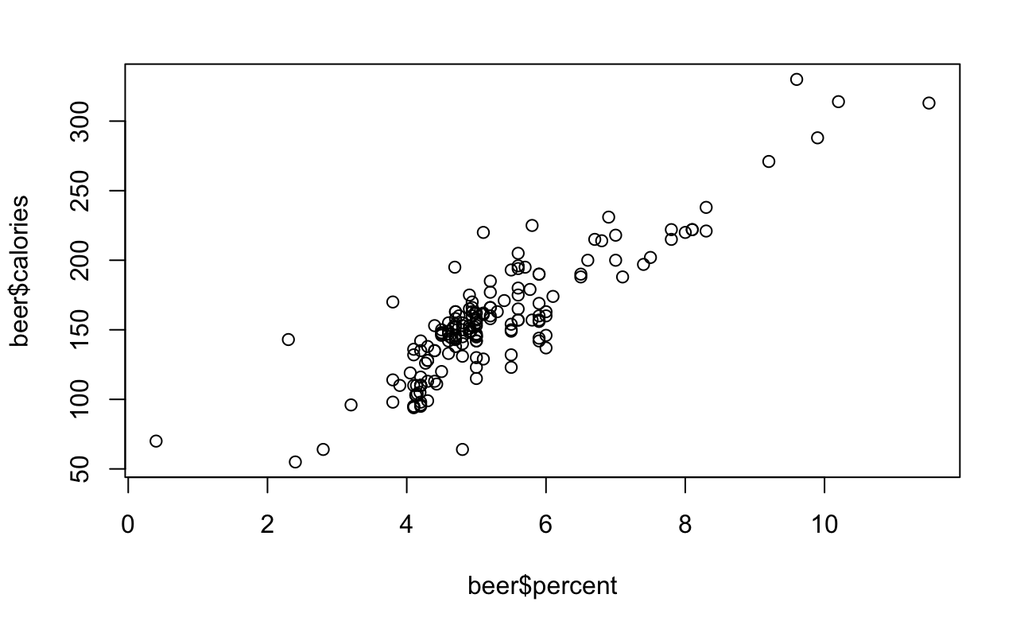

```r
plot(beer$percent, beer$calories)
```

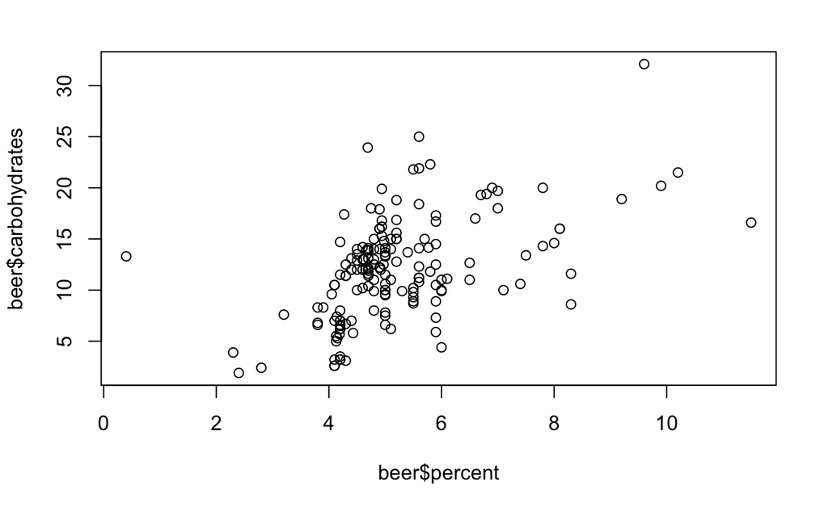

```r
plot(beer$percent, beer$carbohydrates)
```

[Harder] Summarise the beers produced by each brewery.

```r
numeric_beer <- beer[, 3:5]
numeric_beer <- na.omit(numeric_beer)
by(numeric_beer, beer$brewer, summary)
```

```
beer$brewer: Adolph Coors
    percent         calories     carbohydrates
 Min.   :4.100   Min.   : 94.0   Min.   : 2.6
 1st Qu.:4.130   1st Qu.:103.0   1st Qu.: 5.0
 Median :4.430   Median :111.0   Median : 5.8
 Mean   :4.792   Mean   :124.2   Mean   : 6.6
 3rd Qu.:5.400   3rd Qu.:142.0   3rd Qu.: 5.9
 Max.   :5.900   Max.   :171.0   Max.   :13.7
---------------------------------------------------------
beer$brewer: Anchor
    percent       calories   carbohydrates
 Min.   :4.9   Min.   :153   Min.   :16
 1st Qu.:4.9   1st Qu.:153   1st Qu.:16
 Median :4.9   Median :153   Median :16
 Mean   :4.9   Mean   :153   Mean   :16
 3rd Qu.:4.9   3rd Qu.:153   3rd Qu.:16
 Max.   :4.9   Max.   :153   Max.   :16
---------------------------------------------------------
beer$brewer: Anheuser Busch
    percent         calories     carbohydrates
 Min.   :0.400   Min.   : 70.0   Min.   : 2.600
 1st Qu.:4.100   1st Qu.: 95.0   1st Qu.: 6.700
 Median :4.600   Median :133.0   Median :10.200
 Mean   :4.415   Mean   :129.6   Mean   : 9.838
 3rd Qu.:5.000   3rd Qu.:157.0   3rd Qu.:13.300
 Max.   :5.900   Max.   :175.0   Max.   :17.900
---------------------------------------------------------
beer$brewer: Bard's Tale Beer Co
    percent       calories   carbohydrates
 Min.   :4.6   Min.   :155   Min.   :14.2
 1st Qu.:4.6   1st Qu.:155   1st Qu.:14.2
 Median :4.6   Median :155   Median :14.2
 Mean   :4.6   Mean   :155   Mean   :14.2
 3rd Qu.:4.6   3rd Qu.:155   3rd Qu.:14.2
 Max.   :4.6   Max.   :155   Max.   :14.2
---------------------------------------------------------
beer$brewer: Beamish - Crawford (Ireland)
    percent     calories   carbohydrates
 Min.   :5   Min.   :146   Min.   :10
 1st Qu.:5   1st Qu.:146   1st Qu.:10
```

[output cut: 286 more lines]

```
 Min.   :4.40   Min.   :113   Min.   : 7.00
 1st Qu.:4.45   1st Qu.:122   1st Qu.: 8.25
 Median :4.50   Median :131   Median : 9.50
 Mean   :4.50   Mean   :131   Mean   : 9.50
 3rd Qu.:4.55   3rd Qu.:140   3rd Qu.:10.75
 Max.   :4.60   Max.   :149   Max.   :12.00
---------------------------------------------------------
beer$brewer: Summit Brewing
    percent       calories   carbohydrates
 Min.   :4.5   Min.   :147   Min.   :12.00
 1st Qu.:4.8   1st Qu.:159   1st Qu.:12.75
 Median :5.1   Median :171   Median :13.50
 Mean   :5.1   Mean   :171   Mean   :13.50
 3rd Qu.:5.4   3rd Qu.:183   3rd Qu.:14.25
 Max.   :5.7   Max.   :195   Max.   :15.00
```

2.2 TEMPERATURE

Plot the average maximum temperature for each year

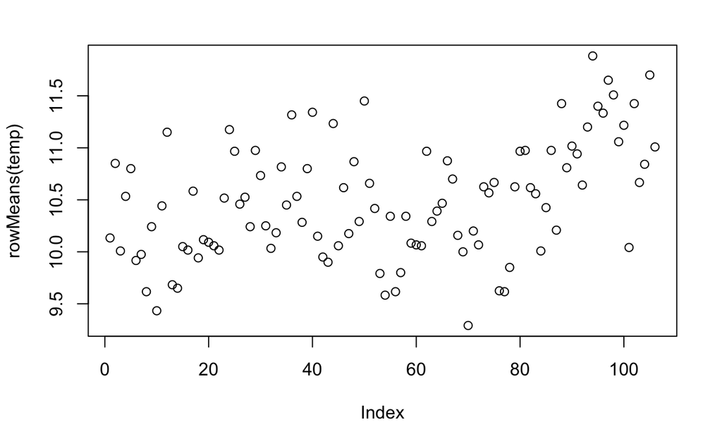

```r
plot(rowMeans(temp))
```

Plot a histogram showing the spread of temperatures

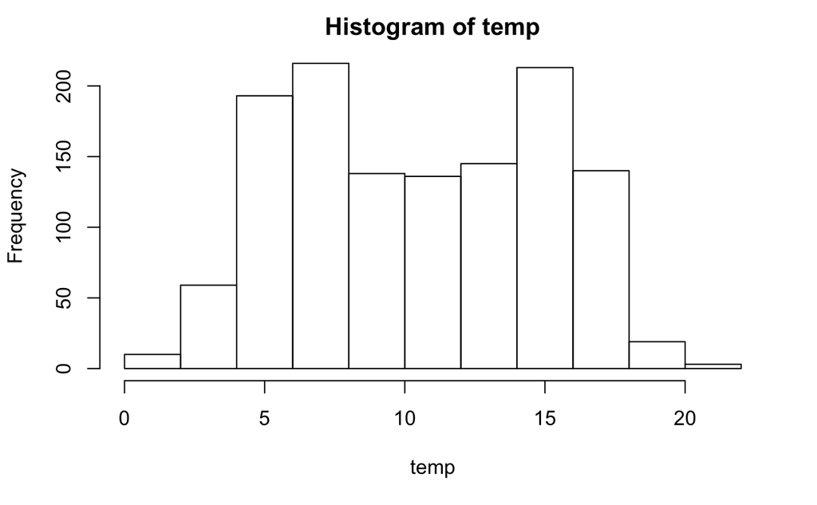

```r
hist(temp)
```

2.3 GAME OF THRONES

[Harder] Make a bar plot showing the distribution of gender for all characters.

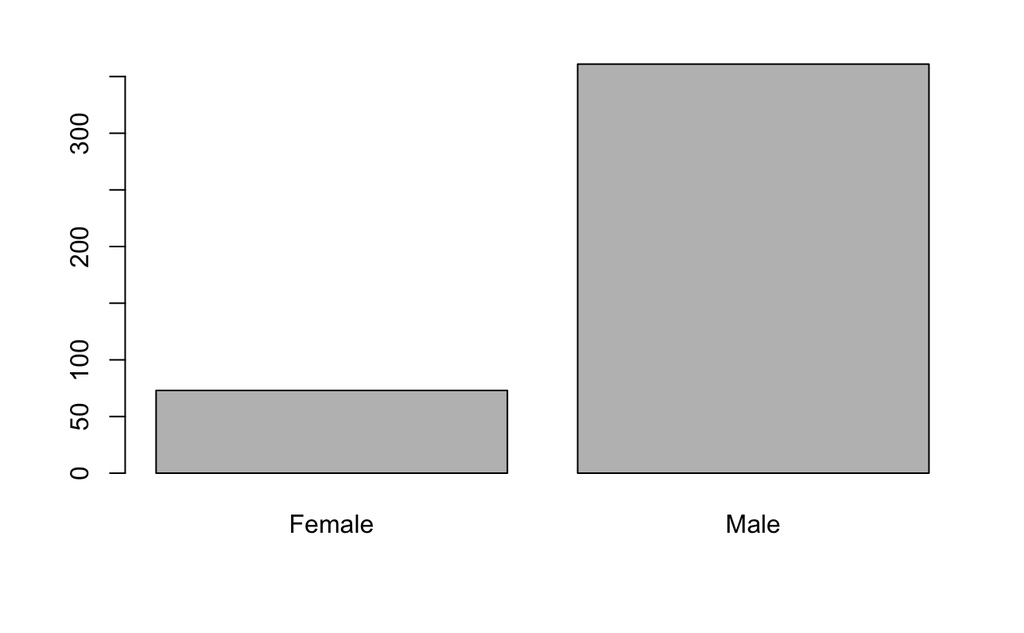

```r
# unlisting using base R tools is pretty annoying, but we can do something like this
chars <- game_of_thrones$characters
chars_df <- as.data.frame(matrix(unlist(chars), nrow = length(chars), byrow = TRUE))
names(chars_df) <- c("Name", "Gender")

barplot(table(chars_df$Gender))
```